# samplesim: an R package for estimating sample size effects in stable isotope mixing solutions

Nicolas Casajus, Nicolas Lecomte and Dorothee Ehrich

2017-05-11

This package allows the investigation of the effect of sample size on estimates and precision of stable isotope mixing solutions calculated with the package [**siar**](https://cran.r-project.org/web/packages/siar/index.html). Samples sizes are modified assuming a normal distribution with a user defined mean and standard deviation. Samples of different sizes are created from this distribution, and mixing proportions are estimated for several replicates of each sample size using the function `siar::siarmcmcdirchletv4()` and default values for the MCMC.

# 1 Package installation

The **samplesim** package is hosted on the GitHub platform (github.com/ahasverus/samplesim). To install this package, you first need to install the **devtools** package from the CRAN. This package provides some useful functions such as the `install_github()` function which allows the installation of packages hosted in GitHub.

```r
# Install the < devtools > package
install.packages("devtools", dependencies = TRUE)

# Load the < devtools > package
library(devtools)

# Install the < samplesim > package from GitHub
devtools::install_github("ahasverus/samplesim")

# Load the < samplesim > package
library(samplesim)
```

Once the **samplesim** package is loaded in your working environment, you can type some useful command lines to get started.

```r
# List the content (objects and functions) of the < samplesim > package
ls("package:samplesim")

# Open the < samplesim > package home page
help(package = "samplesim")

# Open the help file of a specific function
help(plot_samplesim)

# Open the vignette (current document)
browseVignettes(package = "samplesim")
```

# 2 Data description

Let’s take a look at the data requirements. **samplesim** needs two type of data: one for the isotopic plasma values of the consumers (hereafter called `dataConsumer`) and one for the isotopic plasma values of the preys (hereafter called `dataPrey`).

Datasets provided in this package come from Killengreen *et al.* (2011)[^1]

## 2.1 Consumers data

The `dataConsumer` dataset contains the isotopic plasma values of the consumers over two isotopes. It must be structured in a data frame with at least two variables (one by isotope):

- `d13C`, describing the plasma values of the d13C isotope
- `d15N`, describing the plasma values of the d15N isotope

Each row of the data frame corresponds to one consumer. Let’s import the `dataConsumer` dataset available in the **samplesim** package.

```r
# Import isotopic plasma values of the consumers
data(dataConsumer)

# Print the first ten rows
head(dataConsumer, 10)
```

```
##      d13C  d15N
## 1  -23.93  8.67
## 2  -24.30  8.42
## 3  -21.46 10.41
## 4  -23.50  8.71
## 5  -24.40  8.55
## 6  -23.96  8.69
## 7  -24.20  8.75
## 8  -20.62  9.20
## 9  -23.64  8.71
## 10 -22.69 10.20
```

- **Important:** make sure that column names are spelled such as in the above example.

## 2.2 Preys data

The `dataPrey` dataset contains the isotopic plasma values of the preys over two isotopes. It must be structured in a data frame with five variables :

- `Sources`, the name of the sources (preys or groups of preys)
- `Meand13C`, the mean values of the d13C isotope
- `SDd13C`, the standard deviation of the d13C isotope
- `Meand15N`, the mean values of the d15N isotope
- `SDd15N`, the standard deviation of the d15N isotope

Each row of the data frame corresponds to one source (prey or group of preys). Let’s import the `dataPrey` dataset available in the **samplesim** package.

```r
# Import isotopic plasma values of the preys
data(dataPrey)

# Print the data frame content
dataPrey
```

[output not shown]

- **Important:** make sure that column names are spelled such as in the above example.

```r
# Import raw isotopic plasma values of the preys
data(rawPrey)

# Print the first ten rows
head(rawPrey, 10)
```

```
##    Species   d13C d15N
## 1   Micoec -27.80 2.79
## 2   Micoec -27.30 2.31
## 3   Micoec -26.87 5.67
## 4   Micoec -27.25 5.49
## 5   Micoec -26.77 4.29
## 6   Micoec -26.77 4.81
## 7   Micoec -28.39 2.74
## 8   Micoec -27.80 4.08
## 9   Micoec -27.95 4.98
## 10  Micoec -27.89 2.85
```

The function `format_sources()` converts these raw data in the format of `dataPrey` by computing the mean and standard deviation of each isotope for each source. It is important to note that species can be grouped into sources (see below).

```r
# List species names
levels(rawPrey$Species)
```

```
## [1] "Laglag" "Lagmut" "Lemlem" "Melnig" "Micoec" "Rantar" "Ristri" "Urilom"
```

```r
# Group preys species into sources
(src <- list(
  Marine    = c("Ristri", "Urilom"),
  Reindeer  = c("Rantar"),
  Voles     = c("Micoec"),
  Lemming   = c("Lemlem"),
  Ptarmigan = c("Laglag", "Lagmut"),
  Birds     = c("Melnig")))
```

```
## $Marine
## [1] "Ristri" "Urilom"
##
## $Reindeer
## [1] "Rantar"
##
## $Voles
## [1] "Micoec"
##
## $Lemming
## [1] "Lemlem"
##
## $Ptarmigan
## [1] "Laglag" "Lagmut"
##
## $Birds
## [1] "Melnig"
```

```r
# Format preys data
(dataPrey <- format_sources(data = rawPrey, labels = src))
```

```
##     Sources Meand13C SDd13C Meand15N SDd15N
## 1    Marine    -19.2    0.9     11.7    1.1
## 2  Reindeer    -25.4    1.2      2.3    1.4
## 3     Voles    -27.8    0.7      3.6    1.4
## 4   Lemming    -27.9    1.2      1.5    0.8
## 5 Ptarmigan    -25.5    0.8      1.2    0.8
## 6     Birds    -23.8    0.8      7.3    0.2
```

- **Note:** even if preys species do not have to be grouped, their labels need to be stored in a list. For example:

```r
# Prey species names
(species <- c("Marine", "Birds", "Voles"))
```

```
## [1] "Marine" "Birds"  "Voles"
```

```r
# R List conversion
(src <- as.list(species))
```

```
## [[1]]
## [1] "Marine"
##
## [[2]]
## [1] "Birds"
##
## [[3]]
## [1] "Voles"
```

```r
# Name elements of the list
names(src) <- species

# Print list
src
```

```
## $Marine
## [1] "Marine"
##
## $Birds
## [1] "Birds"
##
## $Voles
## [1] "Voles"
```

# 3 Running samplesim

Make sure your data have the following format and the same column names:

- Consumer dataset

```
##     d13C  d15N
## 1 -23.93  8.67
## 2 -24.30  8.42
## 3 -21.46 10.41
## 4 -23.50  8.71
## 5 -24.40  8.55
## 6 -23.96  8.69
```

- Prey dataset

```
##     Sources Meand13C SDd13C Meand15N SDd15N
## 1    Marine    -19.2    0.9     11.7    1.1
## 2  Reindeer    -25.4    1.2      2.3    1.4
## 3     Voles    -27.8    0.7      3.6    1.4
## 4   Lemming    -27.9    1.2      1.5    0.8
## 5 Ptarmigan    -25.5    0.8      1.2    0.8
## 6     Birds    -23.8    0.8      7.3    0.2
```

The core function of **samplesim** is `samplesim()`. It allows investigating the effect of sample size on estimates and precision of stable isotope mixing solutions. More specifically `samplesim()` assesses the sensitivity of isotopes mixing models to variation in numbers of samples from source tissues. This tool can be used prior to full-blown studies in a similar manner than power analyses. It used the function `siar::siarmcmcdirichletv4()` developed by Andrew Parnell and available in the package **siar**. User can choose to sample one particular source, or all the sources. User can also choose to modify consumer data. Sample sizes are modified assuming a normal distribution with a user defined mean and standard deviation. Samples of different sizes are created from this distribution, and mixing proportions are estimated for several replicates of each sample size.

The general writing of `samplesim()` is:

```r
samplesim(
  target,
  sources,
  type = NULL,
  nsamples = NULL,
  modwhich = NULL,
  correct = NULL,
  nrep = 100,
  interval = 90,
  name = NULL)
```

with:

- `target`, the consumers dataset (see Consumers data section).
- `sources`, the preys dataset (see Preys data section).
- `type`, the type of analysis to be run. Must be one of `one source`, `all sources` or `consumer`.
- `nsamples`, the sample sizes to simulate.
- `modwhich`, an integer indicating which source has to be modified.
- `correct`, [optional] a data frame with discrimination values. See [**siar**](https://cran.r-project.org/web/packages/siar/index.html) for further details.
- `nrep`, the number of replicates for each sample sizes.
- `interval`, an integer indicating the width of credible interval to use for precision estimation.
- `name`, the name of the simulation. If `NULL` the simulation will be named by the time of the simulation. This name will serve to create a directory in which results will be stored.

Let’s take an example. We will assess the impact of the sample size of one source: the source #3 (*Voles*) with several sample sizes (from 2 to 250). The analysis will be repeated 500 times.

```r
# samplesim run for one source
samplesim(
  target = dataConsumer,
  source = dataPrey,
  type = "one source",
  modwhich = 3,
  nsamples = c(2:10, 15, 25, 50, 75, 100, 250),
  nrep = 500,
  interval = 90,
  name = "simulation_1")
```

This function does not return any object in the R console. Instead, results are stored in the directory `simulation_1` and they will need to be imported for results visualization (see below section).

# 4 Results extraction

The `samplesim()` function has stored four objects results.

```r
# Content of the new directory (results)
dir("simulation_1")
```

```
## [1] "datasets.rds"  "intervals.rds" "logfile.txt"   "medians.rds"
## [5] "widths.rds"
```

- `intervals`, a four dimensions array with the upper and lower bounds of the credible interval for each sample size, replicate and source. First dimension represents lower and upper bounds; second dimension corresponds to the number of sources; third dimension is the number of replicates; and fourth dimension is the number of sample size.
- `widths`, a three dimensions array with the width (precision) of credible intervals for each source, each replicate and each sample size. First dimension corresponds to the number of replicates; second dimension is the number of sources; and third dimension represents the number of sample size.
- `medians`, a three dimensions array with the median (estimate) of credible intervals for each source, each replicate and each sample size. Dimensions are the same as for `widths` object.
- `datasets`, a four dimensions array with all resampled datasets.

A `logfile` is also written and contains all parameters of the simulation. Here’s what it looks like.

```
## ====================================================
##         SampleSim - User-defined parameters
## ====================================================
##
## Simulation name: simulation_1
## Date: 2017-05-11 20:04:30
##
## Type of sampling: one source
## Modified source: 3
## Modified source name: Voles
## Number of replicates by sample size: 500
## Sample sizes: 2, 3, 4, 5, 6, 7, 8, 9, 10, 15, 25, 50, 75, 100, 250
## Credible intervals width: 90
##
## ====================================================
```

Now, let’s take a look at the results and import the `medians` dataset using the R function `readRDS()`.

```r
# Import medians of credible intervals
medians <- readRDS("simulation_1/medians.rds")
```

```r
# Structure of the object
class(medians)
```

```
## [1] "array"
```

```r
# Names of the dimensions
names(dimnames(medians))
```

```
## [1] "replicate" "source"    "size"
```

```r
# Names of the content of the second dimension
dimnames(medians)[[2]]
```

```
## [1] "Marine"    "Reindeer"  "Voles"     "Lemming"   "Ptarmigan" "Birds"
```

```r
# Names of the content of the third dimension
dimnames(medians)[[3]]
```

```
##  [1] "size2"   "size3"   "size4"   "size5"   "size6"   "size7"   "size8"
##  [8] "size9"   "size10"  "size15"  "size25"  "size50"  "size75"  "size100"
## [15] "size250"
```

These data are structured in a three dimensions array.

```r
# Extract results of the first replicate
medians[1, , ]
```

```
##            size
## source           size2      size3      size4      size5      size6
##   Marine    0.44056964 0.34367463 0.41942970 0.42441250 0.39891502
##   Reindeer  0.02277762 0.02192498 0.02147427 0.02162338 0.02018477
##   Voles     0.27139944 0.10774543 0.21766387 0.23420655 0.19380058
##   Lemming   0.03272121 0.04527839 0.03366181 0.03458937 0.03758984
##   Ptarmigan 0.01806236 0.01630769 0.01699015 0.01717621 0.01652527
##   Birds     0.18335927 0.42999716 0.26044236 0.23913525 0.30016881
##            size
## source           size7      size8      size9     size10     size15
##   Marine    0.45117752 0.39296722 0.42424728 0.34555568 0.41889334
##   Reindeer  0.02292149 0.02045585 0.02085456 0.02058105 0.02182890
##   Voles     0.26577286 0.17864463 0.20898948 0.12023560 0.21312375
##   Lemming   0.03340812 0.03830171 0.03698583 0.04092994 0.03633414
##   Ptarmigan 0.01766369 0.01622218 0.01611851 0.01602517 0.01658676
##   Birds     0.17924909 0.32530220 0.26420246 0.42368731 0.26243512
##            size
## source          size25     size50     size75    size100    size250
##   Marine    0.43054241 0.39235577 0.39760205 0.36406499 0.39360484
##   Reindeer  0.02096739 0.02105150 0.02076083 0.02118111 0.02101038
##   Voles     0.23413392 0.18931437 0.18805629 0.14073403 0.17474988
##   Lemming   0.03365445 0.03663037 0.03623997 0.03987439 0.03652429
##   Ptarmigan 0.01639482 0.01674353 0.01582694 0.01596953 0.01633445
##   Birds     0.23395836 0.31718856 0.31445131 0.38526991 0.31964311
```

```r
# Compute mean over replicates
apply(medians, 3:2, mean)
```

```
##          source
## size         Marine   Reindeer     Voles    Lemming  Ptarmigan     Birds
##   size2   0.3845603 0.02206563 0.1647709 0.04018220 0.01709647 0.3389215
##   size3   0.3889754 0.02181493 0.1740140 0.03927205 0.01690780 0.3268359
##   size4   0.3876880 0.02157205 0.1703348 0.03931223 0.01671111 0.3323985
##   size5   0.3899691 0.02148008 0.1727298 0.03906916 0.01661002 0.3283200
##   size6   0.3904654 0.02140435 0.1744004 0.03888918 0.01658020 0.3264966
##   size7   0.3894935 0.02127449 0.1737872 0.03889504 0.01652219 0.3283821
##   size8   0.3912143 0.02133838 0.1738023 0.03880673 0.01648115 0.3266236
##   size9   0.3905484 0.02130438 0.1738235 0.03873911 0.01645179 0.3276071
##   size10  0.3905093 0.02131332 0.1748833 0.03871902 0.01647894 0.3267229
##   size15  0.3952798 0.02131454 0.1814598 0.03828852 0.01643050 0.3160170
##   size25  0.3944026 0.02119593 0.1799808 0.03828717 0.01638669 0.3189047
##   size50  0.3929238 0.02111277 0.1781991 0.03835007 0.01632999 0.3222655
##   size75  0.3935278 0.02113297 0.1793107 0.03831881 0.01633568 0.3207533
##   size100 0.3936173 0.02111144 0.1788859 0.03846064 0.01630610 0.3206772
##   size250 0.3926408 0.02110731 0.1782771 0.03829733 0.01626092 0.3228451
```

The structure of the `widths` dataset is the same as for `medians`.

If you are uncomfortable to deal with three dimensions arrays, you can use the function `get_output()` of the **samplesim** package. This function converts these two arrays (i.e. `medians` and `widths`) into an unique data frame. For instance:

```r
# Import medians and widths of credible intervals
datas <- get_output("simulation_1")

# Structure of the data frame
str(datas)
```

```
## 'data.frame':    90000 obs. of  5 variables:
##  $ size     : Factor w/ 15 levels "2","3","4","5",..: 1 2 3 4 5 6 7 8 9 10 ...
##  $ source   : Factor w/ 6 levels "Birds","Lemming",..: 3 3 3 3 3 3 3 3 3 3 ...
##  $ replicate: Factor w/ 500 levels "1","2","3","4",..: 1 1 1 1 1 1 1 1 1 1 ...
##  $ value    : num  0.211 0.251 0.245 0.233 0.259 ...
##  $ type     : Factor w/ 2 levels "Width of credible intervals",..: 1 1 1 1 1 1 1 1 1 1 ...
```

```r
# Print the first ten and last ten rows
rbind(head(datas, 10), tail(datas, 10))
```

```
##       size source replicate     value                             type
## 1        2 Marine         1 0.2108666      Width of credible intervals
## 2        3 Marine         1 0.2508832      Width of credible intervals
## 3        4 Marine         1 0.2445866      Width of credible intervals
## 4        5 Marine         1 0.2329192      Width of credible intervals
## 5        6 Marine         1 0.2592167      Width of credible intervals
## 6        7 Marine         1 0.2187157      Width of credible intervals
## 7        8 Marine         1 0.2597722      Width of credible intervals
## 8        9 Marine         1 0.2466002      Width of credible intervals
## 9       10 Marine         1 0.2591252      Width of credible intervals
## 10      15 Marine         1 0.2499743      Width of credible intervals
## 89991    7  Birds       500 0.3239187 Median of posterior distribution
## 89992    8  Birds       500 0.2128412 Median of posterior distribution
## 89993    9  Birds       500 0.4987994 Median of posterior distribution
## 89994   10  Birds       500 0.2635448 Median of posterior distribution
## 89995   15  Birds       500 0.3037672 Median of posterior distribution
## 89996   25  Birds       500 0.4049739 Median of posterior distribution
## 89997   50  Birds       500 0.3354842 Median of posterior distribution
## 89998   75  Birds       500 0.3275730 Median of posterior distribution
## 89999  100  Birds       500 0.2585493 Median of posterior distribution
## 90000  250  Birds       500 0.2860298 Median of posterior distribution
```

If you want to select only the `widths` data,

```r
# Import medians of credible intervals
widths <- datas[datas$type == "Width of credible intervals", ]

# Check
rbind(head(widths, 10), tail(widths, 10))
```

```
##       size source replicate     value                        type
## 1        2 Marine         1 0.2108666 Width of credible intervals
## 2        3 Marine         1 0.2508832 Width of credible intervals
## 3        4 Marine         1 0.2445866 Width of credible intervals
## 4        5 Marine         1 0.2329192 Width of credible intervals
## 5        6 Marine         1 0.2592167 Width of credible intervals
## 6        7 Marine         1 0.2187157 Width of credible intervals
## 7        8 Marine         1 0.2597722 Width of credible intervals
## 8        9 Marine         1 0.2466002 Width of credible intervals
## 9       10 Marine         1 0.2591252 Width of credible intervals
## 10      15 Marine         1 0.2499743 Width of credible intervals
## 44991    7  Birds       500 0.5633861 Width of credible intervals
## 44992    8  Birds       500 0.4614183 Width of credible intervals
## 44993    9  Birds       500 0.4699703 Width of credible intervals
## 44994   10  Birds       500 0.5044309 Width of credible intervals
## 44995   15  Birds       500 0.5445486 Width of credible intervals
## 44996   25  Birds       500 0.5052186 Width of credible intervals
## 44997   50  Birds       500 0.5602326 Width of credible intervals
## 44998   75  Birds       500 0.5762227 Width of credible intervals
## 44999  100  Birds       500 0.5474618 Width of credible intervals
## 45000  250  Birds       500 0.5409510 Width of credible intervals
```

The argument *change* of the function `get_output()` allows to compute the percentage of change of medians and widths respectively, based on a value of sample size (argument *reference*; default is the minimum sample size). For instance,

```r
# Import medians and widths of credible intervals expressed as percentage of change
datas <- get_output("simulation_1", change = TRUE, reference = 2)

# Structure of the data frame
str(datas)
```

```
## 'data.frame':    180 obs. of  4 variables:
##  $ size  : Factor w/ 15 levels "2","3","4","5",..: 1 2 3 4 5 6 7 8 9 10 ...
##  $ source: Factor w/ 6 levels "Birds","Lemming",..: 3 3 3 3 3 3 3 3 3 3 ...
##  $ value : num  0 1.1 0.8 1.4 1.5 1.3 1.7 1.6 1.5 2.8 ...
##  $ type  : Factor w/ 2 levels "Width of credible intervals",..: 1 1 1 1 1 1 1 1 1 1 ...
```

```r
# Print the first ten and last ten rows
rbind(head(datas, 10), tail(datas, 10))
```

```
##     size source value                             type
## 1      2 Marine   0.0      Width of credible intervals
## 2      3 Marine   1.1      Width of credible intervals
## 3      4 Marine   0.8      Width of credible intervals
## 4      5 Marine   1.4      Width of credible intervals
## 5      6 Marine   1.5      Width of credible intervals
## 6      7 Marine   1.3      Width of credible intervals
## 7      8 Marine   1.7      Width of credible intervals
## 8      9 Marine   1.6      Width of credible intervals
## 9     10 Marine   1.5      Width of credible intervals
## 10    15 Marine   2.8      Width of credible intervals
## 171    7  Birds   7.2 Median of posterior distribution
## 172    8  Birds   7.2 Median of posterior distribution
## 173    9  Birds   8.0 Median of posterior distribution
## 174   10  Birds   7.9 Median of posterior distribution
## 175   15  Birds   8.4 Median of posterior distribution
## 176   25  Birds   9.6 Median of posterior distribution
## 177   50  Birds  10.7 Median of posterior distribution
## 178   75  Birds  11.5 Median of posterior distribution
## 179  100  Birds  11.5 Median of posterior distribution
## 180  250  Birds  11.6 Median of posterior distribution
```

Here we notice that the column replicate is omitted and percentages of change are aggregated over replicates.

# 5 Results visualization

The **samplesim** package also offers the possibility of visualizing the effect of sample size on the width of the credible interval and on the median of the posterior distribution of the mixing models. This is possible with the function `plot_samplesim()`.

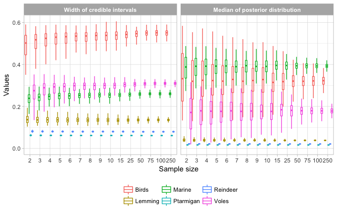

```r
# Visualize results
plot_samplesim(name = "simulation_1")
```

If you prefer you can represent the percentages of change:

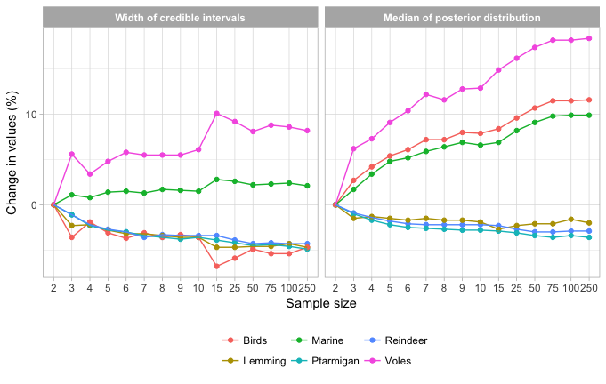

```r
# Visualize results expressed as percentages of change
plot_samplesim(name = "simulation_1", change = TRUE, reference = 2)
```

Finally, if you are not satisfied with the quality of the graph, you can customized it by 1) importing data and 2) programming your own graph. Let’s take an example with the [**ggplot2**](https://cran.r-project.org/web/packages/ggplot2/index.html) package (used in **samplesim**).

```r
# Import medians and widths of credible intervals
datas <- get_output("simulation_1")

# Reminder #1
head(datas)
```

```
##   size source replicate     value                        type
## 1    2 Marine         1 0.2108666 Width of credible intervals
## 2    3 Marine         1 0.2508832 Width of credible intervals
## 3    4 Marine         1 0.2445866 Width of credible intervals
## 4    5 Marine         1 0.2329192 Width of credible intervals
## 5    6 Marine         1 0.2592167 Width of credible intervals
## 6    7 Marine         1 0.2187157 Width of credible intervals
```

```r
# Reminder #2
tail(datas)
```

```
##       size source replicate     value                             type
## 89995   15  Birds       500 0.3037672 Median of posterior distribution
## 89996   25  Birds       500 0.4049739 Median of posterior distribution
## 89997   50  Birds       500 0.3354842 Median of posterior distribution
## 89998   75  Birds       500 0.3275730 Median of posterior distribution
## 89999  100  Birds       500 0.2585493 Median of posterior distribution
## 90000  250  Birds       500 0.2860298 Median of posterior distribution
```

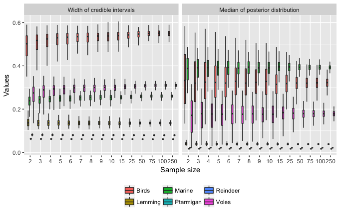

```r
# Graph
ggplot(aes(x = size, y = value), data = datas) +
  geom_boxplot(aes(fill = source), width = 0.8, outlier.shape = NA) +
  labs(x = "Sample size", y = "Values", fill = "Sources") +
  theme(legend.position = "bottom") +
  theme(legend.title = element_blank()) +
  facet_grid(. ~ type)
```

Or your can only represent the medians values. For instance (with percentages of change):

```r
# Import medians and widths of credible intervals
datas <- get_output("simulation_1", change = TRUE)

# Select medians of credible intervals
medians <- datas[datas$type == "Median of posterior distribution", ]

# Print data
head(medians)
```

```
##    size source value                             type
## 91    2 Marine   0.0 Median of posterior distribution
## 92    3 Marine   1.7 Median of posterior distribution
## 93    4 Marine   3.4 Median of posterior distribution
## 94    5 Marine   4.8 Median of posterior distribution
## 95    6 Marine   5.2 Median of posterior distribution
## 96    7 Marine   5.9 Median of posterior distribution
```

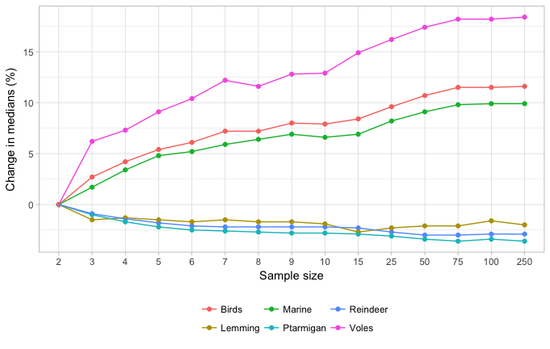

```r
# Graph
ggplot(aes(x = size, y = value, group = source), data = medians) +
  geom_point(aes(color = source)) +
  geom_line(aes(color = source)) +
  labs(x = "Sample size", y = "Change in medians (%)", color = "Sources") +
  theme_light() +
  theme(legend.position = "bottom") +
  theme(legend.title = element_blank())
```

# Reference

Lecomte N., Ehrich D., Casajus N., Berteaux D., Giroux M.-A. and Yoccoz N.G. How many is enough? An R package for evaluating the effect of sample size on estimates and precision of stable isotope mixing solutions. *Methods in Ecology and Evolution*, submitted.

[^1]: Killengreen S., Lecomte N., Ehrich D., Schott T., Yoccoz N.G. and Ims R.A. (2011) The importance of marine vs. human-induced subsidies in the maintenance of an expanding mesocarnivore in the arctic tundra. *Journal of Animal Ecology*, **80**, 1049-1060.